# Analisi su Cardiopatie

### di Plantos Dan Stefan

# Fonti

1. *"Cardiovascular Disease"*, di **Aidan**, al [link](https://www.kaggle.com/datasets/colewelkins/cardiovascular-disease), questo dataset consolida informazioni provenienti da due sorgenti primarie:
   1. [UCI Machine Learning Repository - Heart Disease Dataset](https://archive.ics.uci.edu/dataset/45/heart+disease)
   2. [Kaggle - Heart Disease Dataset by YasserH](https://www.kaggle.com/datasets/yasserh/heart-disease-dataset)
2. *"Cardiovascular Disease Dataset"*, di **Svetlana Ulianova**, al [link](https://www.kaggle.com/datasets/sulianova/cardiovascular-disease-dataset), questo dataset consolida informazioni provenienti da visite svolte in un ospedale canadese di Toronto.

# Attributi del dataset

- `id`
- `età`
- `genere`
- `altezza`
- `peso`
- `sistolica`
- `diastolica`
- `arteriosa`
- `bmi`
- `fumatore`
- `alcolista`
- `colesterolo`
- `glucosio`
- `sportivo`
- `cardiopatico`

# Quesiti per l'analisi:

1. L'età influisce sulla probabilità di avere una malattia cardiovascolare?
2. La pressione arteriosa (sistolica e diastolica) ha un impatto rilevante sul rischio?
3. Quanto incide il fumo o il consumo di alcol?
4. Ci sono differenze di rischio tra uomini e donne?
5. Le persone attive fisicamente sono più protette?
6. Esistono correlazioni tra BMI e malattia?
7. Quali sono le variabili più predittive di una malattia cardiovascolare?
8. Un livello di colesterolo alto può influenzare il sorgere di una malattia cardiovascolare?
9. Un livello di glucosio alto può influenzare il sorgere di una malattia cardiovascolare?
10. Esiste una relazione tra colesterolo, glucosio e rischio di CHD?
11. Esiste una relazione tra fumo, colesterolo e causa di CVD?

## 1) Esiste una relazione tra fumo, colesterolo e rischio di cardiopatia?

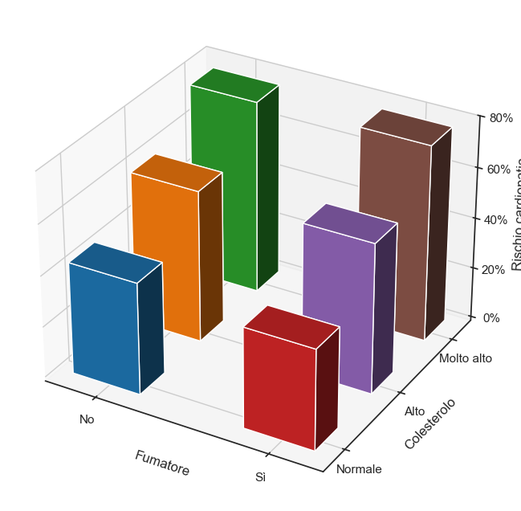

## 2) L'età influisce sul rischio di cardiopatia?

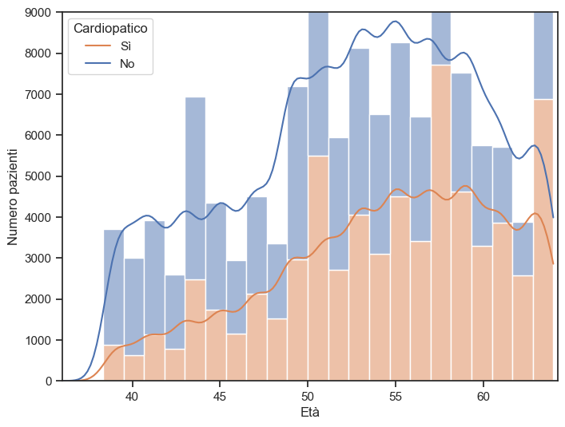

## 3) La pressione arteriosa, sistolica e diastolica ha un impatto sul rischio di cardiopatia?

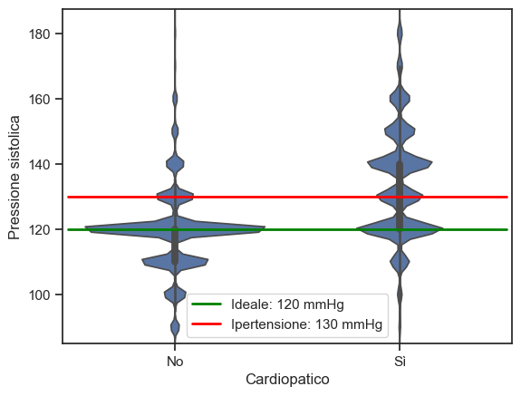

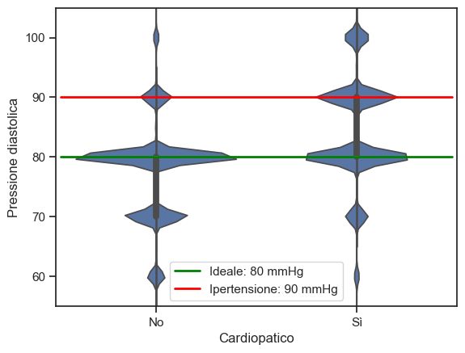

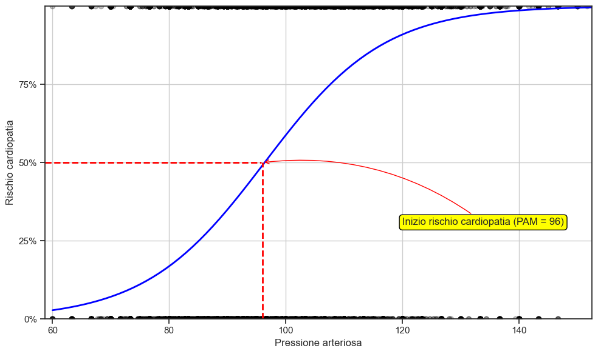

$$ \boxed{ PAM = \text{pressione diastolica} + \left( \frac{\text{pressione sistolica} - \text{pressione diastolica}}{3} \right) } $$

## 4) Quanto incide il fumo o il consumo di alcol (o entrambe)?

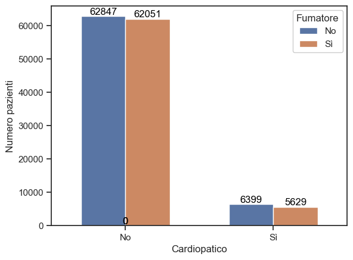

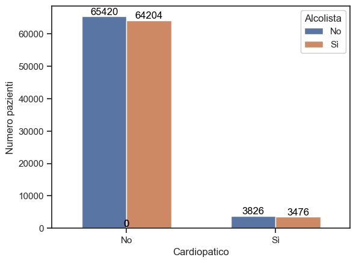

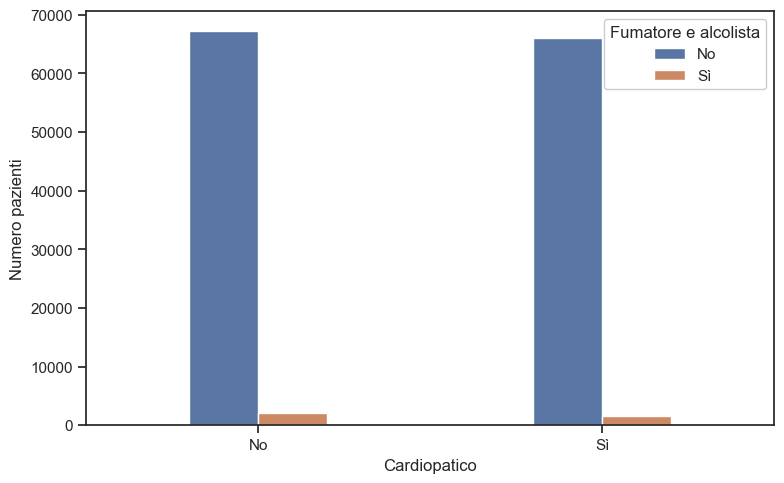

## 5) Ci sono differenze di rischio tra uomini e donne?

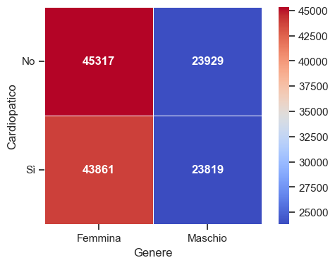

## 6) Le persone attive fisicamente sono più protette?

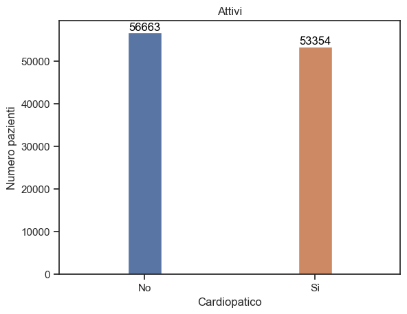

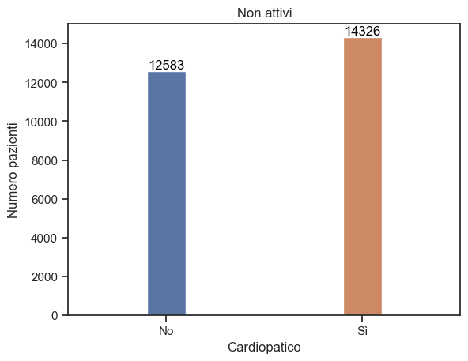

## 7) Esistono correlazioni tra BMI e malattia cardiovascolare?

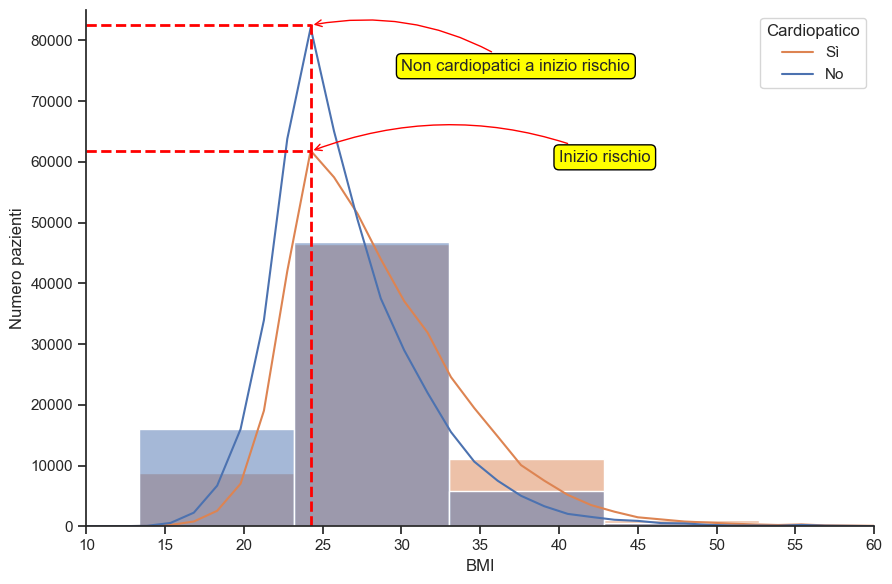

$$ \boxed{ BMI = \frac{\text{peso} \left( \text{kg} \right)}{\text{altezza}^2 \left( \text{m}^2 \right)} } $$

## 8) Quali sono le variabili più predittive di una malattia cardiovascolare?

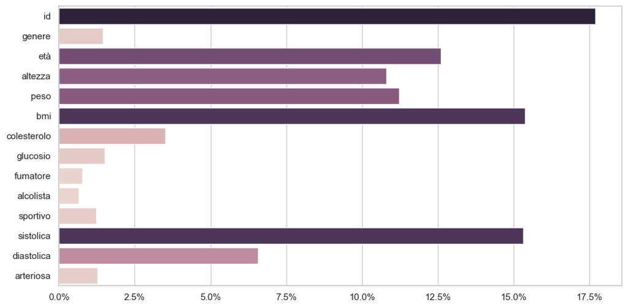

## 9) Un livello di colesterolo alto può influenzare il sorgere di una malattia cardiovascolare?

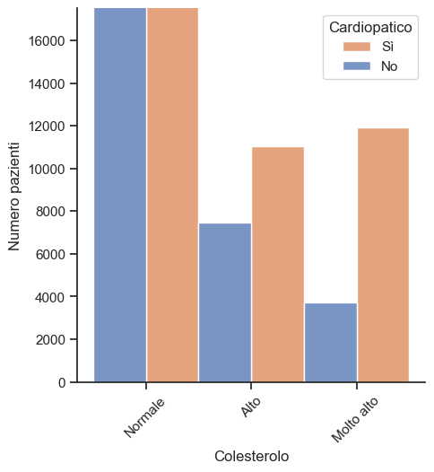

## 10) Un livello di glucosio alto può influenzare il sorgere di una malattia cardiovascolare?

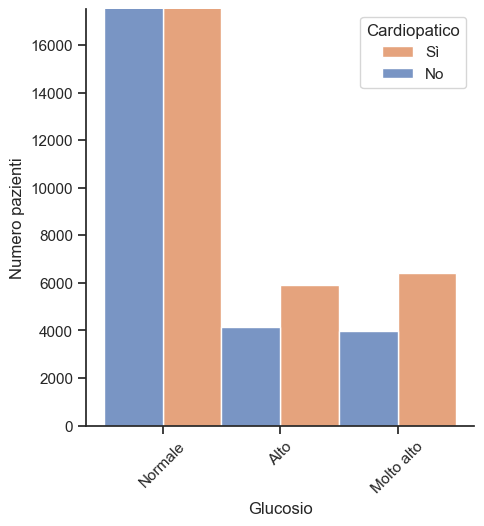

## 11) Esiste una relazione tra colesterolo, glucosio e rischio di coronarie?

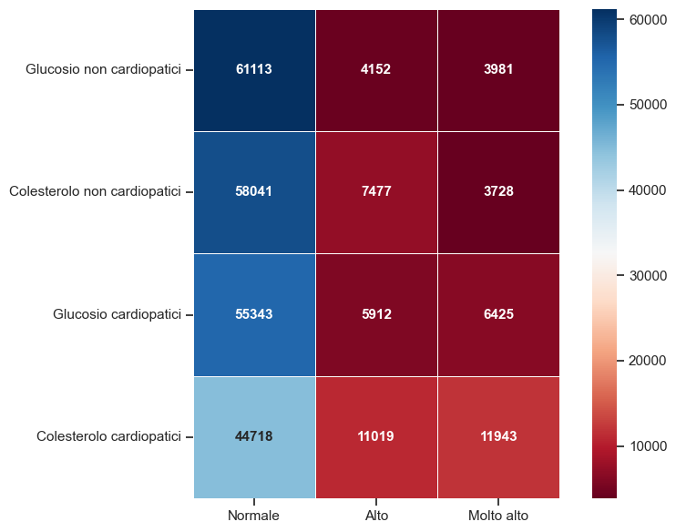

# Conclusioni